# 608_JR_FInal_Project

Jeyaraman Ramalingam

5/21/2021

## Overview

Terrorism is a never ending nemesis for the Global Community. Every Year , the threat because of terrorism is growing making it essential to look back and find out the vulnerable regions, countries and provinces/states. This would provide the government organizations necessary insights to take better decisions on handling the Global Terrorism.

## Data Source

Data Source URL - https://gtd.terrorismdata.com/files/gtd-1970-2019-4/

The GTD is an open-source database, which provides information on domestic and international terrorist attacks around the world since 1970, and now includes more than 200,000 events. For each event, a wide range of information is available, including the date and location of the incident, the weapons used, nature of the target, the number of casualties, and – when identifiable – the group or individual responsible.

```
##  [1] "ï..iyear"        "imonth"          "iday"            "country"
##  [5] "country_txt"     "region"          "region_txt"      "provstate"
##  [9] "city"            "attacktype1"     "attacktype1_txt" "attacktype2"
## [13] "attacktype2_txt" "attacktype3"     "attacktype3_txt"
```

The Input datasource has lot of unnecessary columns which are not required for this research. Hence the next step is to drop the columns apart from the below columns

- iyear
- imonth
- iday
- country
- country_txt
- region
- region_txt
- provstate
- city
- attacktype1
- attacktype1_txt
- attacktype2
- attacktype2_txt
- attacktype3
- attacktype3_txt

## Data Exploration and Preparation

### Data Subsetting

| iyear | imonth | iday | country | country_txt | region | region_txt | provstate | city | attacktype1 | attacktype1_txt | attacktype2 | attacktype2_txt | attacktype3 | attacktype3_txt |
| --- | --- | --- | --- | --- | --- | --- | --- | --- | --- | --- | --- | --- | --- | --- |
| 1970 | 7 | 2 | 58 | Dominican Republic | 2 | Central America & Caribbean | National | Santo Domingo | 1 | Assassination | NA |  | NA |  |
| 1970 | 0 | 0 | 130 | Mexico | 1 | North America | Federal | Mexico city | 6 | Hostage Taking (Kidnapping) | NA |  | NA |  |
| 1970 | 1 | 0 | 160 | Philippines | 5 | Southeast Asia | Tarlac | Unknown | 1 | Assassination | NA |  | NA |  |
| 1970 | 1 | 0 | 78 | Greece | 8 | Western Europe | Attica | Athens | 3 | Bombing/Explosion | NA |  | NA |  |
| 1970 | 1 | 0 | 101 | Japan | 4 | East Asia | Fukouka | Fukouka | 7 | Facility/Infrastructure Attack | NA |  | NA |  |
| 1970 | 1 | 1 | 217 | United States | 1 | North America | Illinois | Cairo | 2 | Armed Assault | NA |  | NA |  |

### Summary Statistics

```
##      iyear          imonth            iday          country
##  Min.   :1970   Min.   : 0.000   Min.   : 0.00   Min.   :   4.0
##  1st Qu.:1992   1st Qu.: 4.000   1st Qu.: 8.00   1st Qu.:  75.0
##  Median :2011   Median : 6.000   Median :15.00   Median : 101.0
##  Mean   :2004   Mean   : 6.452   Mean   :15.52   Mean   : 131.4
##  3rd Qu.:2015   3rd Qu.: 9.000   3rd Qu.:23.00   3rd Qu.: 160.0
##  Max.   :2019   Max.   :12.000   Max.   :31.00   Max.   :1004.0
##
##  country_txt            region        region_txt         provstate
##  Length:201183      Min.   : 1.000   Length:201183      Length:201183
##  Class :character   1st Qu.: 6.000   Class :character   Class :character
##  Mode  :character   Median : 8.000   Mode  :character   Mode  :character
##                     Mean   : 7.254
##                     3rd Qu.:10.000
##                     Max.   :12.000
##
##      city            attacktype1    attacktype1_txt     attacktype2
##  Length:201183      Min.   :1.000   Length:201183      Min.   :1.00
##  Class :character   1st Qu.:2.000   Class :character   1st Qu.:2.00
##  Mode  :character   Median :3.000   Mode  :character   Median :2.00
##                     Mean   :3.315                      Mean   :3.87
##                     3rd Qu.:3.000                      3rd Qu.:7.00
##                     Max.   :9.000                      Max.   :9.00
##                                                        NA's   :193485
##  attacktype2_txt     attacktype3     attacktype3_txt
##  Length:201183      Min.   :1.00     Length:201183
##  Class :character   1st Qu.:3.00     Class :character
##  Mode  :character   Median :7.00     Mode  :character
##                     Mean   :5.55
##                     3rd Qu.:7.00
##                     Max.   :7.00
##                     NA's   :200613
```

### Missing Data Check

```
##           iyear          imonth            iday         country     country_txt
##               0               0               0               0               0
##          region      region_txt       provstate            city     attacktype1
##               0               0               0               0               0
## attacktype1_txt     attacktype2 attacktype2_txt     attacktype3 attacktype3_txt
##               0          193485               0          200613               0
```

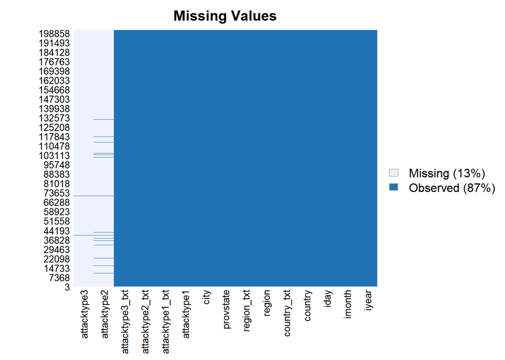

The miss map output and Column Summaries shows us that the attack type 2 and 3 fields are not significant for the research. The next step is to drop the insignificant columns from the dataset

### Data Subsetting - Missing Columns

```
##           iyear          imonth            iday         country     country_txt
##               0               0               0               0               0
##          region      region_txt       provstate            city     attacktype1
##               0               0               0               0               0
## attacktype1_txt
##               0
```

The Column Summaries shows us that there are no missing values.